# Density plots of t test statistic under H1

Benedict Kongyir

12/06/2023

```r
num.sim <- 1e5
n <- 10
df <- 3
deltavec <- c(0.5, 1 ,1.5)
```

```r
tstat_norm <- tstat_chi <- tstat_exp <- tstat_unif <- tstat_t <- tstat_gamma <- tstat_weibull <- tstat_log <- matrix(NA, nrow = num.sim, ncol = length(deltavec))
```

```r
set.seed(123)
for(i in 1:num.sim){
  for (k in 1:length(deltavec)){
    chisq_distn <- (rchisq(n, df) - df)/sqrt(2*df) + deltavec[k]
    exp_distn <- (rexp(n) - 1) + deltavec[k]
    unif_distn <- (runif(n, 0, 1) - 0.5)/sqrt(1/12) + deltavec[k]
    t_distn <- (rt(n, df))/sqrt(df/(df-2)) + deltavec[k]
    norm_dist<- rnorm(n) + deltavec[k]
    gamma_dist <- ((rgamma(n, shape = 3, rate = 0.1) - 30)/sqrt(300)) + deltavec[k]
    log_dist <- (rlnorm(n, meanlog = 0, sdlog = 1)- exp(0+1/2))/sqrt(sqrt((exp(1)-1)*exp(2*0 + 1))) + deltavec[k]

    tstat_chi[i, k] <- sqrt(n)*mean(chisq_distn)/sd(chisq_distn)
    tstat_norm[i, k] <- sqrt(n)*mean(norm_dist)/sd(norm_dist)
    tstat_exp[i, k] <- sqrt(n)*mean(exp_distn)/sd(exp_distn)
    tstat_t[i, k] <- sqrt(n)*mean(t_distn)/sd(t_distn)
    tstat_unif[i, k] <- sqrt(n)*mean(unif_distn)/sd(unif_distn)
    tstat_gamma[i, k] <- sqrt(n)*mean(gamma_dist)/sd(gamma_dist)
    tstat_log[i, k] <- sqrt(n)*mean(log_dist)/sd(log_dist)
  }
}
```

```r
save.image(paste0("test statistics plot under H1",".RData"))
```

## 0.1 Chi-Squared

### 0.1.1 Observations:

We see that all the density plots of the test statistic for both the Chi-Squared and Normal distribution are right skewed with skewness increasing with the effect size. Compared to the test statistic of samples from normal distribution, the test statistic of the Chi-squared samples has a stronger peak, but less skewed. As effect size increases, the variance also increases.

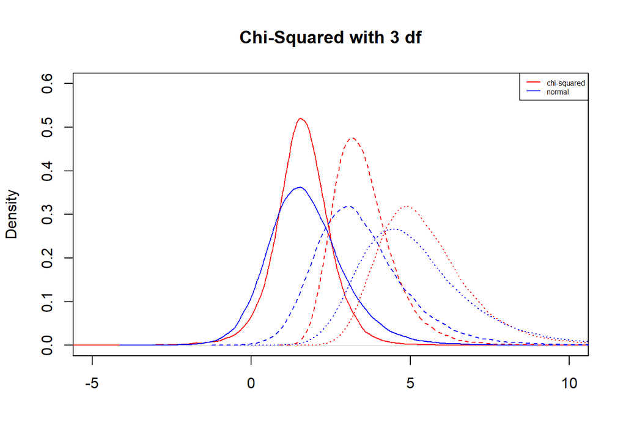

```r
plot(density(tstat_chi[, 1]), typ = "n", xlim = c(-5, 10), ylim = c(0, 0.6), main = " ", xlab = " ")
title(main = "Chi-Squared with 3 df")
for (k in 1:3){
  lines(density(tstat_chi[, k]), col = "red", lty = k)
  lines(density(tstat_norm[, k]), col = "blue", lty = k)
}
legend('topright', legend = c("chi-squared", "normal"), col=c("red", "blue") , lty =1 ,cex = 0.5)
```

## 0.2 Exponential

### 0.2.1 Observations:

We see that all the density plots of the test statistic for both the exponential and Normal distribution are right skewed with skewness increasing with the effect size. Compared to the test statistic of samples from normal distribution, the test statistic of the exponential samples has a stronger peak, but less skewed. As effect size increases, the variance also increases.

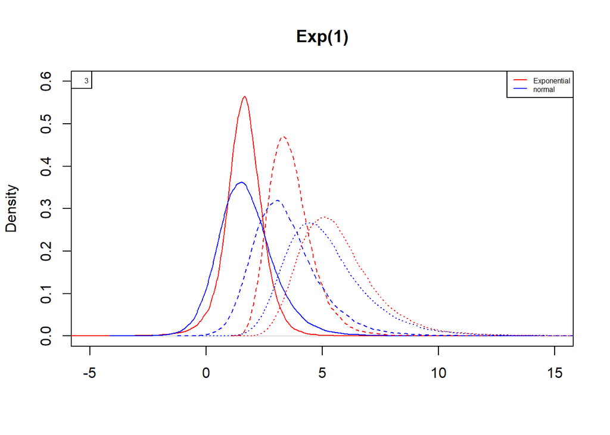

```r
plot(density(tstat_chi[, 1]), typ = "n", xlim = c(-5, 15), ylim = c(0, 0.6), main = " ", xlab = " ")
title(main = "Exp(1)")
for (k in 1:3){
  lines(density(tstat_exp[, k]), col = "red", lty = k)
  lines(density(tstat_norm[, k]), col = "blue", lty = k)

}
legend('topright', legend = c("Exponential", "normal"), col=c("red", "blue") , lty =1 ,cex = 0.5)
legend('topleft', legend = k , cex = 0.5)
```

## 0.3 Uniform

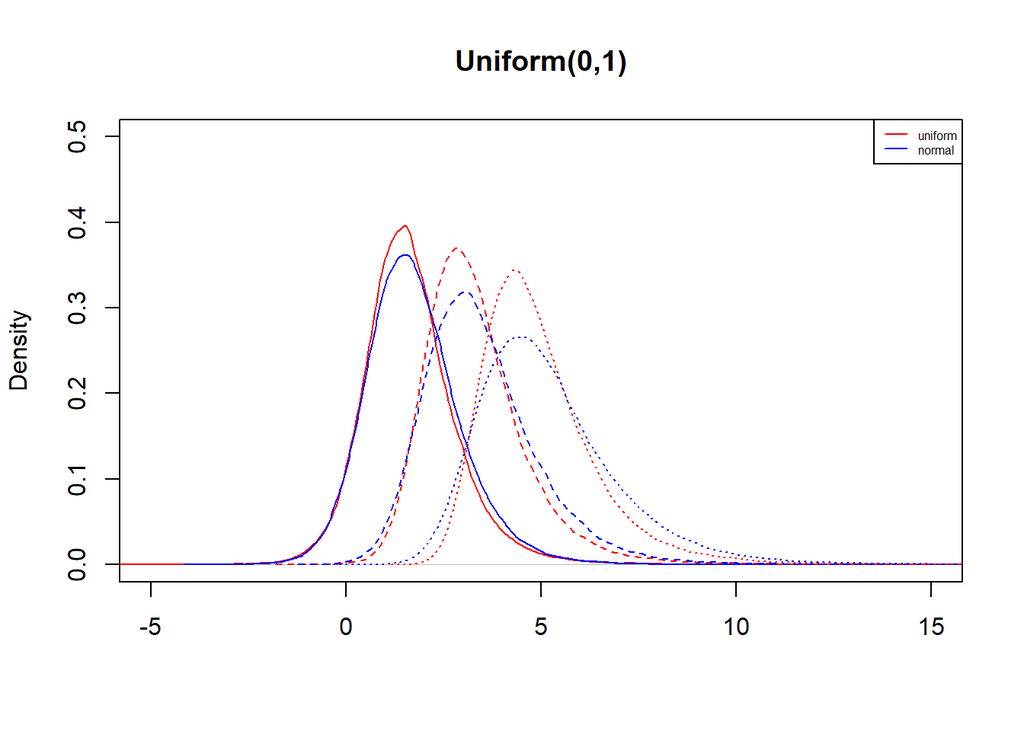

```r
plot(density(tstat_chi[, 1]), typ = "n", xlim = c(-5, 15), ylim = c(0, 0.5), main = " ", xlab = " ")
title(main = "Uniform(0,1)")
for (k in 1:3){
  lines(density(tstat_unif[, k]), col = "red", lty = k)
  lines(density(tstat_norm[, k]), col = "blue", lty = k)

}
legend('topright', legend = c("uniform", "normal"), col=c("red", "blue") , lty =1 ,cex = 0.5)
```

### 0.3.2 t

### 0.3.3 Observations:

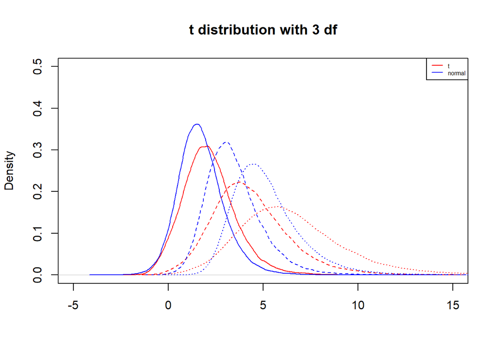

```r
plot(density(tstat_chi[, 1]), typ = "n", xlim = c(-5, 15), ylim = c(0, 0.5), main = " ", xlab = " ")
title(main = "t distribution with 3 df")
for (k in 1:3){
  lines(density(tstat_t[, k]), col = "red", lty = k)
  lines(density(tstat_norm[, k]), col = "blue", lty = k)

}
legend('topright', legend = c("t", "normal"), col=c("red", "blue") , lty =1 ,cex = 0.5)
```

### 0.3.4 Gamma

### 0.3.5 Observations:

We see that all the density plots of the test statistic for both the Gamma and Normal distribution are right skewed with skewness increasing with the effect size. Compared to the test statistic of samples from normal distribution, the test statistic of the Gamma samples has a slightly higher peak. However the peak decreases with effect sizes.

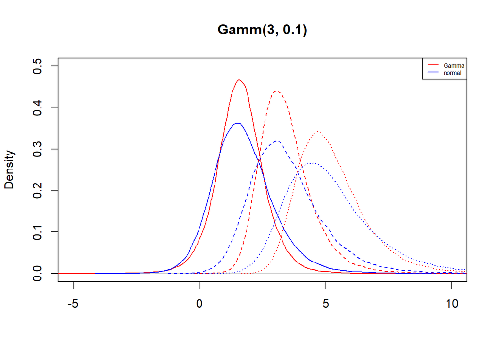

```r
plot(density(tstat_chi[, 1]), typ = "n", xlim = c(-5, 10), ylim = c(0, 0.5), main = " ", xlab = " ")
title(main = "Gamm(3, 0.1)")
for (k in 1:3){
  lines(density(tstat_gamma[, k]), col = "red", lty = k)
  lines(density(tstat_norm[, k]), col = "blue", lty = k)

}
legend('topright', legend = c("Gamma", "normal"), col=c("red", "blue") , lty =1 ,cex = 0.5)
```

### 0.3.6 lognormal

We see that all the density plots of the test statistic for both the Lognormal and Normal distribution are right skewed with skewness increasing with the effect size. Compared to the test statistic of samples from normal distribution, the test statistic of the Lognormal samples has a higher higher peak for smaller effect size but decreases with increase in effect size. The density plots are similar as effect size increases.

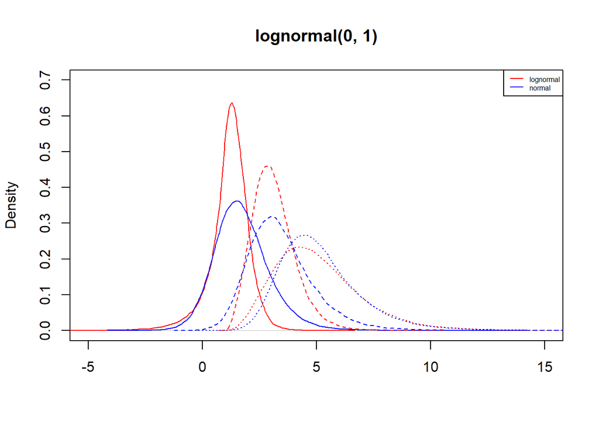

```r
plot(density(tstat_chi[, 1]), typ = "n", xlim = c(-5, 15), ylim = c(0, 0.7), main = " ", xlab = " ")
title(main = "lognormal(0, 1)")
for (k in 1:3){
  lines(density(tstat_log[, k]), col = "red", lty = k)
  lines(density(tstat_norm[, k]), col = "blue", lty = k)

}
legend('topright', legend = c("lognormal", "normal"), col=c("red", "blue") , lty =1 ,cex = 0.5)
```